# Practical 3 Answers

## Visualizing the boys data

8. Visualize the relationship between reg (region) and age using a boxplot.

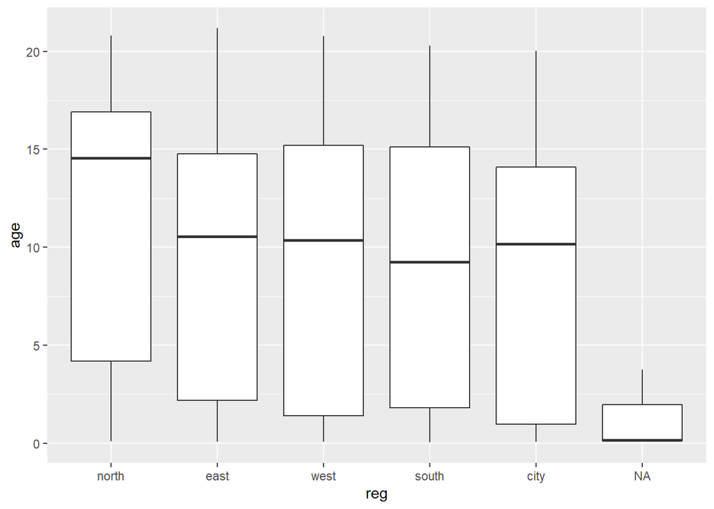

```r
new_boys %>%
  ggplot(aes(x = reg, y = age)) +
  geom_boxplot()
```

9. Create a density plot of age, splitting the densities by gen using the fill aesthetic.

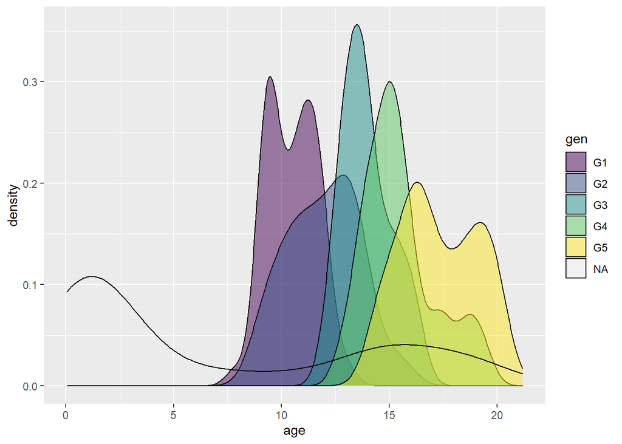

```r
new_boys %>%
  ggplot(aes(x = age, fill = gen)) +
  geom_density(alpha = .5)
```

10. Create a diverging bar chart for hgt in the boys data set, that displays for every age year that year’s mean height in deviations from the overall average hgt.

```r
#SKIPPED
```

# Regression visualization

11. Load the data elastic1 and elastic2 and bind the data frames together using the function bind_rows() and add a grouping variable indicating whether an observation comes from elastic1 or from elastic2.

```r
elastic <- bind_rows("elastic1" = elastic1, "elastic2" = elastic2, .id = "Group")
```

12. Create a scatterplot mapping stretch on the x-axis and distance on the y-axis, and map the just created group indicator as the color aesthetic.

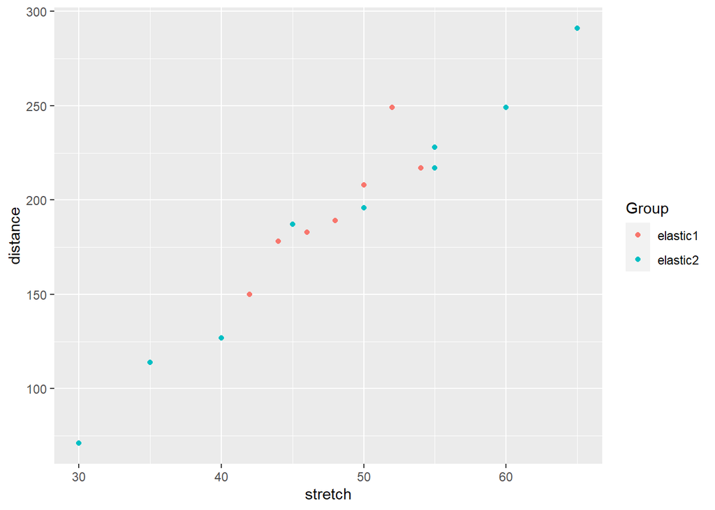

```r
elastic %>%
  ggplot(aes(x=stretch, y=distance, colour=Group)) +
  geom_point()
```

13. Recreate the previous plot, but now assess whether the results of the two data sets appear consistent by adding a linear regression line.

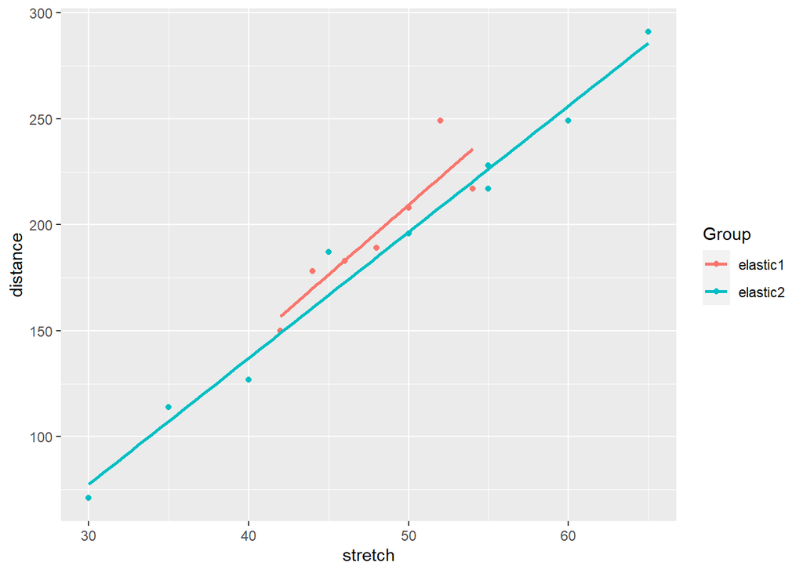

```r
elastic %>%
  ggplot(aes(x=stretch, y=distance, colour=Group)) +
  geom_point() +
  geom_smooth(method = "lm", se = FALSE)
```

14. For each of the data sets elastic1 and elastic2, fit a regression model with y = distance on x = stretch using lm(y ~ x, data).

```r
lm1 <- lm(distance ~ stretch, elastic1)
lm2 <- lm(distance ~ stretch, elastic2)
```

15. For both of the previously created fitted models, determine the fitted values and the standard errors of the fitted values, and the proportion explained variance R2.

```r
predict(lm1, se.fit = TRUE)
```

```
## $fit
##        1        2        3        4        5        6        7
## 183.1429 235.7143 196.2857 209.4286 170.0000 156.8571 222.5714
##
## $se.fit
## [1]  6.586938 10.621119  5.891537  6.586938  8.331891 10.621119  8.331891
##
## $df
## [1] 5
##
## $residual.scale
## [1] 15.58754
```

```r
predict(lm2, se.fit = TRUE)
```

```
## $fit
##         1         2         3         4         5         6         7         8
##  77.58333 196.58333 137.08333 166.83333 256.08333 226.33333 107.33333 226.33333
##         9
## 285.83333
##
## $se.fit
## [1] 6.740293 3.520003 4.358744 3.635444 5.060323 4.064550 5.453165 4.064550
## [9] 6.296773
##
## $df
## [1] 7
##
## $residual.scale
## [1] 10.44202
```

```r
lm1 %>% summary() %$% r.squared
```

```
## [1] 0.7992446
```

```r
lm2 %>% summary() %$% r.squared
```

```
## [1] 0.9807775
```

16. Study the residual versus leverage plots for both models.

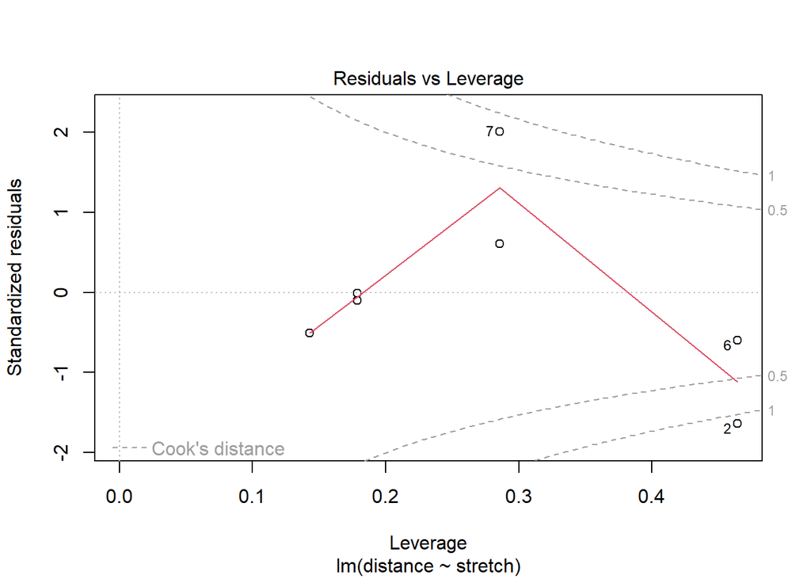

```r
lm1 %>% plot(which = 5)
```

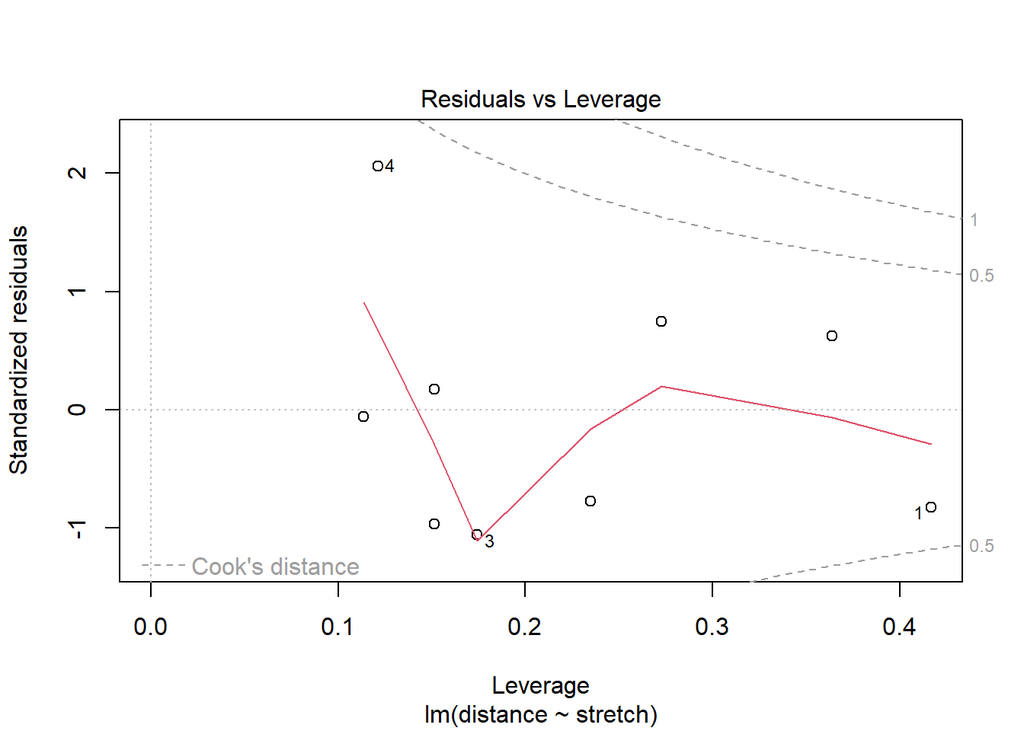

```r
lm2 %>% plot(which = 5)
```

17. Use the elastic2 variable stretch to obtain predictions on the model fitted on elastic1.

```r
pred <- predict(lm1, elastic2)
```

18. Now make a scatterplot to investigate similarity between the predicted values and the observed values for elastic2.

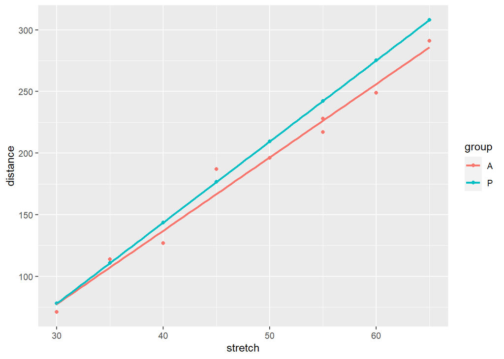

```r
new_stretch <- data.frame(stretch = c(elastic2$stretch, elastic2$stretch),
                          distance = c(pred,elastic2$distance),
                          group = as.factor(c(rep('P', length(pred)),rep('A', length(elastic2$stretch)))))

new_stretch %>%
  ggplot(aes(x = stretch, y= distance, color = group)) +
  geom_point() +
  geom_smooth(method = "lm", se = FALSE)
```